# P2-Investigate a dataset

### Dataset used:titanic data

The following data analysis is done on the titanic data about the passenger provided by kaggle which contains demographics and passenger information from 891 of the 2224 passengers and crew on board the Titanic. This will consist of stating few questions and addressing them in the rest of the analysis process.

#### Imports

```python
%matplotlib inline
import pandas as pd
import seaborn as sns
import numpy as np
import matplotlib.pyplot as plt
```

#### Reading the file

```python
tnc_df=pd.read_csv('titanic_data.csv')
```

```python
tnc_df.shape
```

```
(891, 12)
```

There are 891 observations with 12 variables

#### Preview

```python
tnc_df.head()
```

|  | PassengerId | Survived | Pclass | Name | Sex | Age | SibSp | Parch | Ticket | Fare | Cabin | Embarked |
| --- | --- | --- | --- | --- | --- | --- | --- | --- | --- | --- | --- | --- |
| 0 | 1 | 0 | 3 | Braund, Mr. Owen Harris | male | 22.0 | 1 | 0 | A/5 21171 | 7.2500 | NaN | S |
| 1 | 2 | 1 | 1 | Cumings, Mrs. John Bradley (Florence Briggs Th... | female | 38.0 | 1 | 0 | PC 17599 | 71.2833 | C85 | C |
| 2 | 3 | 1 | 3 | Heikkinen, Miss. Laina | female | 26.0 | 0 | 0 | STON/O2. 3101282 | 7.9250 | NaN | S |
| 3 | 4 | 1 | 1 | Futrelle, Mrs. Jacques Heath (Lily May Peel) | female | 35.0 | 1 | 0 | 113803 | 53.1000 | C123 | S |
| 4 | 5 | 0 | 3 | Allen, Mr. William Henry | male | 35.0 | 0 | 0 | 373450 | 8.0500 | NaN | S |

#### Check for missing values in each column

```python
tnc_df.info()
```

```
<class 'pandas.core.frame.DataFrame'>
RangeIndex: 891 entries, 0 to 890
Data columns (total 12 columns):
PassengerId    891 non-null int64
Survived       891 non-null int64
Pclass         891 non-null int64
Name           891 non-null object
Sex            891 non-null object
Age            714 non-null float64
SibSp          891 non-null int64
Parch          891 non-null int64
Ticket         891 non-null object
Fare           891 non-null float64
Cabin          204 non-null object
Embarked       889 non-null object
dtypes: float64(2), int64(5), object(5)
memory usage: 83.6+ KB
```

```python
#Mapping columns Survived,Embarked and Pclass to more descriptive labels
tnc_df['Survival'] = tnc_df.Survived.map({0 : 'Died', 1 : 'Survived'})
tnc_df['Class'] = tnc_df.Pclass.map({1 : 'First Class', 2 : 'Second Class', 3 : 'Third Class'})
tnc_df['Port'] = tnc_df.Embarked.map({'C' : 'Cherbourg', 'Q' : 'Queenstown', 'S' : 'Southampton'})
```

#### Questions to be answered regarding the dataset

1.What is the number of passengers from each port(Cherbourg,Queenstown and Southampton) and how the survival rate varies with the port embarked?

2.What is the number of people from each class?What is the influence of class on survival rate?

3.What age groups were more likely to survive?

4.Are women more likely to survive or vice versa?

5.Did passenger class favour gender in survival?

6.How did the survival rate vary by age and passenger class?

7.Did the port embarked favour gender in survival rate?

8.Are people with family more likely to survive than others?

#### Dealing with missing values

Since there are lot of missing values in Cabin column,we can't use it for the analysis process As for age values,since most of the data values lie within one standard deviations from the mean,we can fill those null values with random numbers between(mean-std) & (mean+std)

```python
pd.options.mode.chained_assignment = None
age_mean=tnc_df['Age'].mean()
age_std=tnc_df['Age'].std()
nan_age=tnc_df['Age'].isnull().sum()
rand=np.random.randint(age_mean-age_std,age_mean+age_std,size=nan_age)
tnc_df['Age'][np.isnan(tnc_df['Age'])] = rand
tnc_df['Age'].dtype
#Convert the float value to int
tnc_df['Age'] = tnc_df['Age'].astype(int)
```

#### Qn 1:What is the number of passengers from each port(Cherbourg,Queenstown and Southampton) and how the survival rate varies with the port embarked?

```python
tnc_df.groupby('Port').size()
```

```
Port
Cherbourg      168
Queenstown      77
Southampton    644
dtype: int64
```

Fill the missing values in port with the most occuring value 'S'

```python
tnc_df['Port']=tnc_df['Port'].fillna('Southampton')
```

Next,lets investigate the survival rate in each port embarked

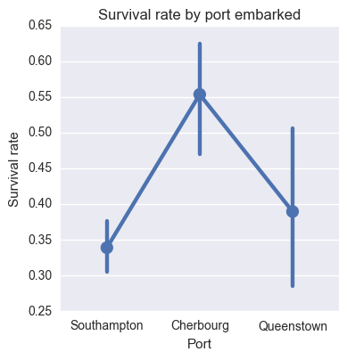

```python
sns.factorplot("Port","Survived",data=tnc_df)
plt.title("Survival rate by port embarked")
plt.ylabel("Survival rate")
```

```python
tnc_df.groupby('Port').mean()['Survived']
```

```
Port
Cherbourg      0.553571
Queenstown     0.389610
Southampton    0.339009
Name: Survived, dtype: float64
```

```python
pd.crosstab(tnc_df['Port'],tnc_df['Survival'],margins=True)
```

| Survival Port | Died | Survived | All |
| --- | --- | --- | --- |
| Cherbourg | 75 | 93 | 168 |
| Queenstown | 47 | 30 | 77 |
| Southampton | 427 | 219 | 646 |
| All | 549 | 342 | 891 |

#### Observations

The maximum number of passengers embarked from Southampton but the survival rate is least The survival rate is highest for people embarked from Cherbourg

#### Qn2:What is the number of people from each class?What is the influence of class on survival rate?

```python
tnc_df.groupby('Class').size()
```

```
Class
First Class     216
Second Class    184
Third Class     491
dtype: int64
```

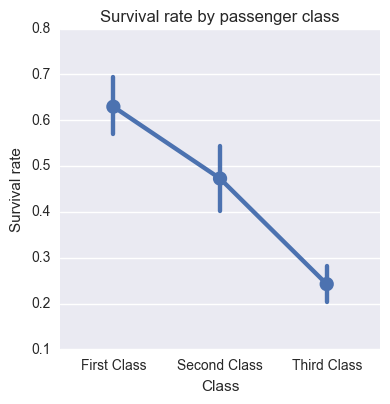

```python
sns.factorplot("Class","Survived",data=tnc_df,order=['First Class','Second Class','Third Class'])
plt.title("Survival rate by passenger class")
plt.ylabel('Survival rate')
```

```python
tnc_df.groupby('Class').mean()['Survived']
```

```
Class
First Class     0.629630
Second Class    0.472826
Third Class     0.242363
Name: Survived, dtype: float64
```

Out of 891 passengers,491 were of 3rd class and the survival rate was least for 3rd class

#### Qn3:What age groups were more likely to survive?

```python
tnc_df['Age'].describe()
```

```
count    891.000000
mean      29.650954
std       13.538142
min        0.000000
25%       21.000000
50%       28.000000
75%       38.000000
max       80.000000
Name: Age, dtype: float64
```

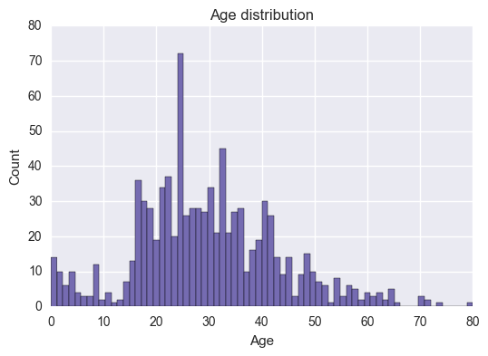

```python
tnc_df['Age'].hist(bins=70,color="#756bb1")
plt.title("Age distribution")
plt.ylabel('Count')
plt.xlabel('Age')
```

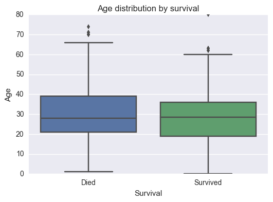

```python
sns.boxplot("Survival","Age",data=tnc_df)
plt.title("Age distribution by survival")
```

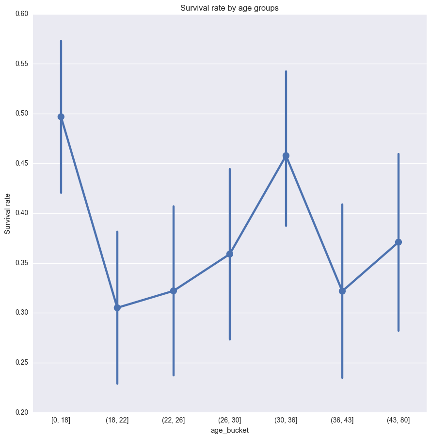

```python
tnc_df['age_bucket'] = pd.qcut(tnc_df['Age'],7)
sns.factorplot('age_bucket','Survived',data=tnc_df,size=9)
plt.title("Survival rate by age groups")
plt.ylabel('Survival rate')
```

It is found that passengers upto 17 years have the highest rate of survival

```python
tnc_df.groupby('Survival').median()['Age']
```

```
Survival
Died        28.0
Survived    28.5
Name: Age, dtype: float64
```

#### Using basic regression to visualise realtionship between age and survival rate

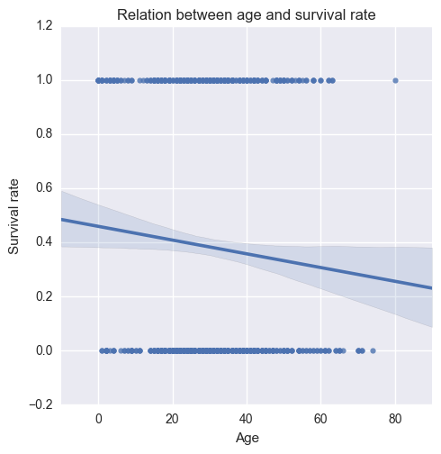

```python
sns.lmplot('Age', 'Survived', data=tnc_df)
plt.title("Relation between age and survival rate")
plt.ylabel('Survival rate')
```

#### Qn4:Are women more likely to survive or vice versa?

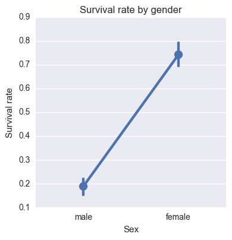

```python
sns.factorplot("Sex","Survived",data=tnc_df)
plt.title("Survival rate by gender")
plt.ylabel('Survival rate')
```

```python
pd.crosstab(tnc_df['Sex'],tnc_df['Survival'],margins=True)
```

| Survival Sex | Died | Survived | All |
| --- | --- | --- | --- |
| female | 81 | 233 | 314 |
| male | 468 | 109 | 577 |
| All | 549 | 342 | 891 |

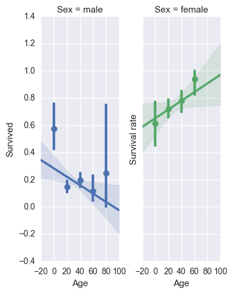

```python
age_bucket=[0,20,40,60,80]
sns.lmplot(x="Age", y="Survived", hue="Sex", col="Sex",data=tnc_df, aspect=.4, x_jitter=.1,x_bins=age_bucket)
plt.ylabel('Survival rate')
```

Lets investigate the survival rate of children.A child is defined as person whose age is less than 18 years old,so I created a new column Person to include children also

```python
#Function to define child category
def male_female_child(passenger):

    age, sex = passenger

    if age <18:
        return 'child'
    else:
        return sex
tnc_df['Person'] = tnc_df[['Age', 'Sex']].apply(male_female_child, axis=1)
```

#### Survival rate by person

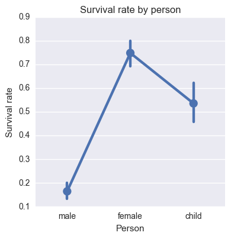

```python
sns.factorplot("Person","Survived",data=tnc_df)
plt.title("Survival rate by person")
plt.ylabel('Survival rate')
```

```python
pd.crosstab(tnc_df['Person'],tnc_df['Survival'],margins=True)
```

| Survival Person | Died | Survived | All |
| --- | --- | --- | --- |
| child | 59 | 68 | 127 |
| female | 64 | 190 | 254 |
| male | 426 | 84 | 510 |
| All | 549 | 342 | 891 |

Women and children have significantly higher survival rates than men

#### Qn 5:Did passenger class favour gender in survival?

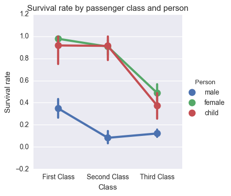

```python
sns.factorplot("Class","Survived",hue="Person",data=tnc_df,order=['First Class','Second Class','Third Class'])
plt.ylabel('Survival rate')
plt.title('Survival rate by passenger class and person')
```

Regardless of the passenger class,men are less likely to survive than women or children

#### Qn 6:How did the survival rate vary by age and passenger class?

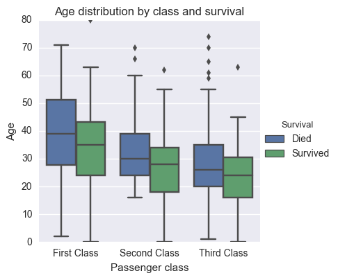

```python
sns.factorplot(x="Class", y="Age", hue="Survival", data=tnc_df, kind="box",order=['First Class','Second Class','Third Class'])
plt.title("Age distribution by class and survival")
plt.xlabel("Passenger class")
```

#### Observations

1.The median age of survival for class 1 passengers is 35 and the median age decrease with class

2.For a given passenger class,the median age of survived passengers is less than passengers who did not survive

#### Qn 7:Did the port embarked favour gender in survival rate?

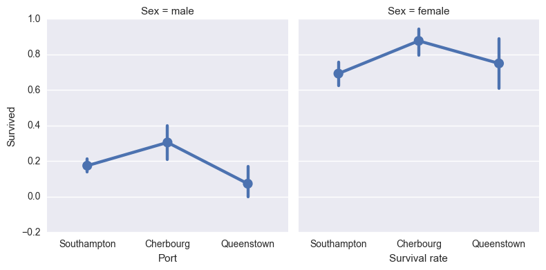

```python
sns.factorplot('Port','Survived',col="Sex",data=tnc_df)
plt.xlabel('Survival rate')
```

Lets see the distribution of males and females embarked from each port

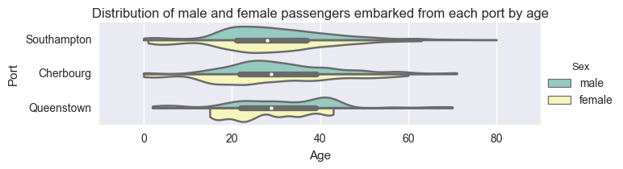

```python
sns.factorplot(x="Age", y="Port",hue="Sex",data=tnc_df,orient="h", size=2, aspect=3.5, palette="Set3",
                    kind="violin", split=True, cut=0, bw=.2)
plt.title("Distribution of male and female passengers embarked from each port by age")
```

```python
pd.crosstab(tnc_df['Port'],tnc_df['Sex'],margins=True)
```

| Sex Port | female | male | All |
| --- | --- | --- | --- |
| Cherbourg | 73 | 95 | 168 |
| Queenstown | 36 | 41 | 77 |
| Southampton | 205 | 441 | 646 |
| All | 314 | 577 | 891 |

#### Observation

1.In all the ports of embarkment,males have a lower rate of survival than females 2.Even though,in all the ports the number of male passengers who embarked are more than the female passengers

#### Qn 8:Are people with family more likely to survive than others?

```python
pd.options.mode.chained_assignment = None
#Creating a new column 'Alone' to identify those passengers who were accompanied by their parents,spouse or siblings
tnc_df['Alone'] = tnc_df['SibSp'] + tnc_df['Parch']

tnc_df['Alone'].loc[tnc_df['Alone'] > 0] = 'With family'
tnc_df['Alone'].loc[tnc_df['Alone'] == 0] = 'Alone'
```

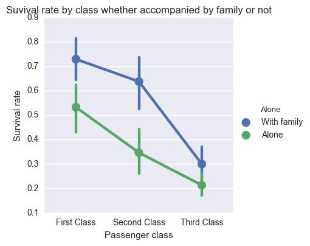

```python
sns.factorplot('Class','Survived',data=tnc_df,hue="Alone",order=['First Class','Second Class','Third Class'])
plt.title("Suvival rate by class whether accompanied by family or not")
plt.ylabel('Survival rate')
plt.xlabel('Passenger class')
```

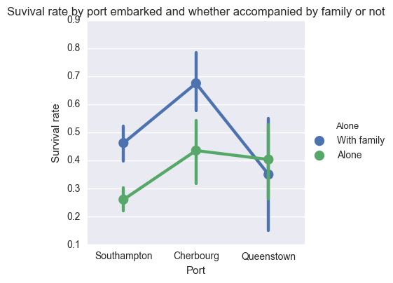

```python
sns.factorplot('Port','Survived',data=tnc_df,hue="Alone")
plt.title("Suvival rate by port embarked and whether accompanied by family or not")
plt.ylabel('Survival rate')
```

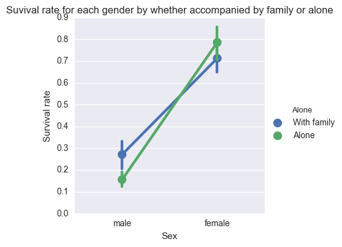

```python
sns.factorplot('Sex','Survived',data=tnc_df,hue="Alone")
plt.title("Suvival rate for each gender by whether accompanied by family or alone")
plt.ylabel('Survival rate')
```

#### Observations

1.When looking at each passenger class,the passengers who were accompanied by a family had more chances of survival than those who were alone

2.Except in Queenstown,the rate of survival for passengers with family was more than those who were alone

### Final results and reflections

### Conclusion

2.Women and children are more likely to survive than men regardless of the passenger class or the port embarked

### Limitations

#### Potential shortcomings of the data analysis process

1.Limitations of assumptions made without using statistical tests:The conclusions that women and children are more likely to survive or surviival rate reduces with age cannot be ascertained without using a statistical test so that we are assured that the results are not due to chance.Also,corelation does not imply causation i.e,the assumption that being a male passenger causes death is not true, but there is a definite relation or corelation between the two variables

2.Missing values in the dataset:There are lot of missing values in the Cabin column.So,we cannot be sure if it was factor which influenced the survival rate.Also,I filled the missing values in age column under the assumptions of the property of a normal distribution.

3.Limitation of linear regression used:Regression works well only if we have lot of data points.Also,these models are sensitive to outliers.More accurate predictions can be made by using machine learning techniques